# Week 1: Introduction & Spatial Descriptions

EE0849 Introduction to Robotics

Basri Erdogan

## This Week’s Goals

1. Define what a **robot** is and survey the field of industrial robotics
2. Review **vectors**, inner products, and cross products
3. Distinguish **position** (3 numbers) from **orientation** (3x3 matrix)
4. Understand **rotation matrices** and the group $SO(3)$
5. Apply **elementary rotations** $R_x$, $R_y$, $R_z$ to transform vectors

## Robots Are Already Everywhere

**3.9 million** industrial robots operating worldwide (IFR 2023)

*Source: International Federation of Robotics (World Robotics 2023).*

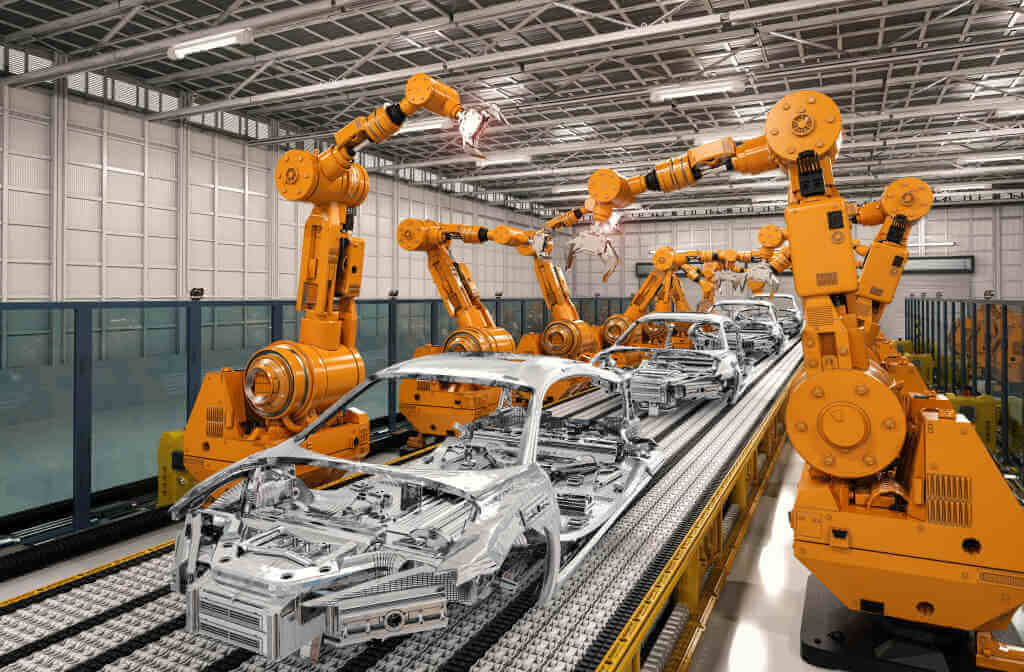

**Manufacturing**

[figure not shown]

**Logistics**

[figure not shown]

**Industrial**

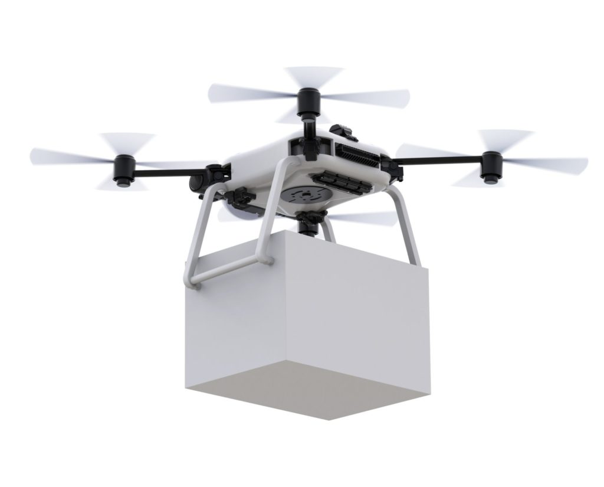

**Aerial**

[figure not shown]

**Humanoid**

[figure not shown]

**Collaborative**

## So Why Do We Still Need Robotics Engineers?

Because every one of these robots needs someone who understands the **math behind the motion**.

# Part 1: Introduction to Robotics

## What is a Robot?

**Core message:** A robot is a **reprogrammable physical system** that can **sense, plan, and act** autonomously.

**ISO 8373 (industrial robot):** *Automatically controlled, reprogrammable, multipurpose manipulator.*

[figure not shown]

## Industrial Robotics Timeline (I): Foundations

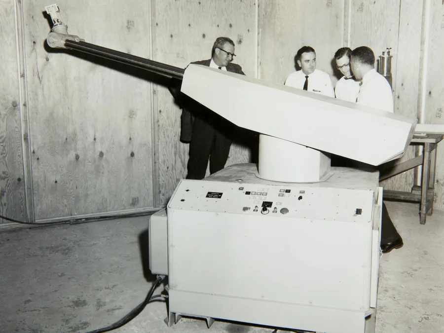

**1961 — Unimate** First industrial robot (GM)

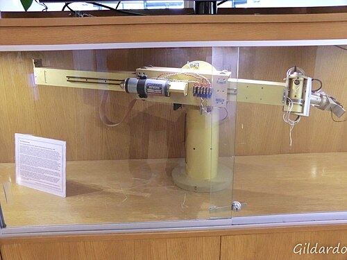

**1969 — Stanford Arm** First electric computer-controlled

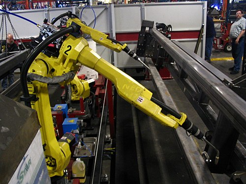

**1978 — FANUC / PUMA** Industrial automation era

## Industrial Robotics Timeline (II): Modern Era

[figure not shown]

**1997 — da Vinci** Surgical robotics revolution

[figure not shown]

**2008 — Universal Robots** Collaborative robots (cobots)

[figure not shown]

**2024 — Humanoid Era** Atlas, Optimus, Figure

*Timeline source context: canonical milestones from manufacturer and industry-history records.*

## Why Study Robotics?

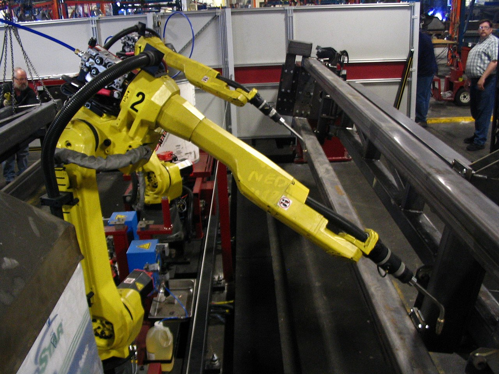

**Manufacturing**

FANUC, ABB, KUKA

[figure not shown]

**Healthcare**

da Vinci surgical system

[figure not shown]

**Exploration**

NASA Mars rovers

[figure not shown]

**Service**

Amazon warehouse robots

> Robotics is where **mechanics**, **electronics**, and **computer science** converge.

## Course Focus

[figure not shown]

## From Intuition to Precision

You can **point** to a robot’s end-effector and say “it’s over there, tilted like this.”

. . .

But a robot controller needs **numbers**:

- **Where** exactly is the tool tip? ($x, y, z$)
- **How** is it oriented? ($R \in SO(3)$)
- **Which path** should it follow to get there?

. . .

This is why we need **coordinate frames** and **transformation math**.

[figure not shown]

# Part 2: Mathematical Foundations

## Coordinate Frames & Free Vectors

- We use Cartesian coordinate systems
- **Inertial Frame (World):** Fixed, denoted as $\{0\}$
- **Body Frame:** Attached to the moving object, denoted as $\{1\}$
- **Vector Notation:**
  - $\mathbf{v}^1$: Vector $\mathbf{v}$ expressed in frame $\{1\}$
  - $\mathbf{v}^0$: Vector $\mathbf{v}$ expressed in frame $\{0\}$
- **Free Vector Transform** (rotation only):
  $$\mathbf{v}^0 = R_1^0 \mathbf{v}^1$$

[figure not shown]

## Point Coordinates

- A **point** has a fixed location in space
- Its coordinates depend on the frame origin **and** orientation
- **Point Transform** (rotation + translation):
  $$\mathbf{p}^0 = \mathbf{p}_1^0 + R_1^0 \mathbf{p}^1$$
- $\mathbf{p}_1^0$: origin of $\{1\}$ expressed in $\{0\}$
- Compare: free vectors need only $R$, points need $R$ **and** $\mathbf{p}_1^0$

[figure not shown]

## Vectors and Inner Products

- A vector is an ordered tuple of numbers: $\mathbf{v} = [v_1, v_2, v_3]^T$
- **Dot Product (Inner Product):**
  $$\mathbf{x} \cdot \mathbf{y} = \mathbf{x}^T \mathbf{y} = \sum_{i=1}^n x_i y_i$$

[figure not shown]

## Vector Norm and Angle

- **Norm (Magnitude):**
  $$\|\mathbf{x}\| = (\mathbf{x}^T \mathbf{x})^{1/2}$$
- **Angle between vectors:**
  $$\mathbf{x} \cdot \mathbf{y} = \|\mathbf{x}\| \|\mathbf{y}\| \cos(\theta)$$
- If $\mathbf{x} \cdot \mathbf{y} = 0$, the vectors are **orthogonal**

[figure not shown]

## Cross Products

- Crucial for defining rotation axes and moments
- $\mathbf{x} \times \mathbf{y}$ produces a vector orthogonal to both $\mathbf{x}$ and $\mathbf{y}$
- **Magnitude:** $\|\mathbf{x} \times \mathbf{y}\| = \|\mathbf{x}\| \|\mathbf{y}\| \sin(\theta)$
- **Direction:** Right-hand rule

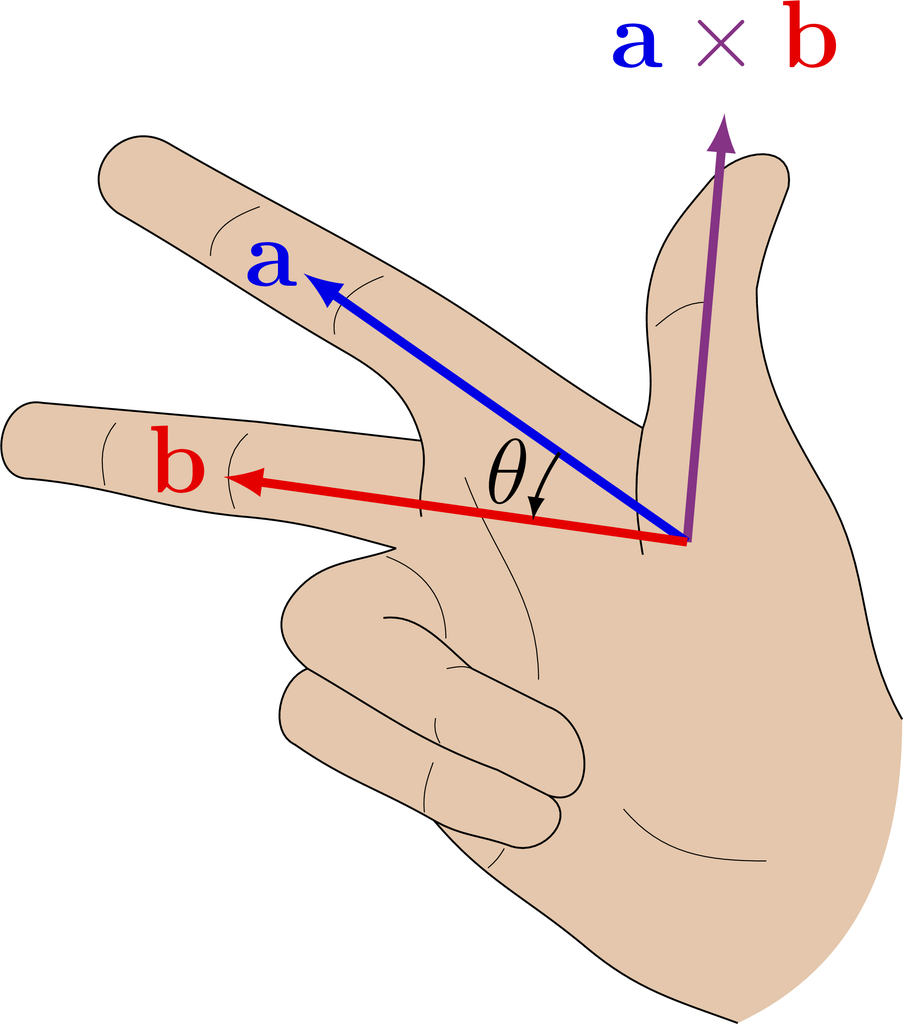

[figure not shown]

## Skew-Symmetric Matrix Operator

- Cross product as matrix multiplication:
  $$\mathbf{x} \times \mathbf{y} = S(\mathbf{x}) \mathbf{y}$$
- **Skew-Symmetric Matrix:**
  $$S(\mathbf{x}) = \begin{bmatrix} 0 & -x_3 & x_2 \\ x_3 & 0 & -x_1 \\ -x_2 & x_1 & 0 \end{bmatrix}$$
- **Property:** $S(\mathbf{x})^T = -S(\mathbf{x})$

[figure not shown]

## Skew-Symmetric Matrix: Example

**Given:** $\mathbf{x} = [1, 2, 3]^T$, $\mathbf{y} = [4, 5, 6]^T$

**Traditional (determinant form):**

$$\mathbf{x} \times \mathbf{y} = \begin{vmatrix} \mathbf{i} & \mathbf{j} & \mathbf{k} \\ 1 & 2 & 3 \\ 4 & 5 & 6 \end{vmatrix}$$

$$= \mathbf{i}(2 \cdot 6 - 3 \cdot 5) - \mathbf{j}(1 \cdot 6 - 3 \cdot 4) + \mathbf{k}(1 \cdot 5 - 2 \cdot 4)$$

$$= \mathbf{i}(-3) - \mathbf{j}(-6) + \mathbf{k}(-3) = \begin{bmatrix} -3 \\ 6 \\ -3 \end{bmatrix}$$

**Using skew-symmetric matrix:**

$$S(\mathbf{x})\mathbf{y} = \begin{bmatrix} 0 & -3 & 2 \\ 3 & 0 & -1 \\ -2 & 1 & 0 \end{bmatrix} \begin{bmatrix} 4 \\ 5 \\ 6 \end{bmatrix}$$

$$= \begin{bmatrix} -3 \\ 6 \\ -3 \end{bmatrix} \checkmark$$

# Part 3: Position vs Orientation

## Position

- A point in 3D space
- Described by **3 numbers**: $\mathbf{p} = [x, y, z]^T$
- Measured relative to a reference frame
- Specifies **where** an object is located

[figure not shown]

## Orientation

- The rotation of a body in space
- Orientation has **3 DOF**, but matrix representation has 9 entries with constraints
- A common representation is a **3×3 rotation matrix** $R$
- Specifies **how** an object is rotated
- Other representations: Euler angles, quaternions

[interactive chart not shown]

## The Key Question

> How do we describe the **state** of a robot link relative to the world?

. . .

- **Position:** Where is the origin of the body frame? → $\mathbf{p} \in \mathbb{R}^3$
- **Orientation:** How is the body frame rotated? → $R \in SO(3)$

. . .

**Next week:** We combine both into a single **homogeneous transformation** $H \in SE(3)$.

[figure not shown]

# Part 4: Rotation Matrices

## Axis Color Convention

- To keep figures and equations consistent:
  - x-axis (red)
  - y-axis (green)
  - z-axis (blue)

## Representing Rotation

- Two frames with the same origin $O$
- Frame $\{1\}$ is rotated relative to Frame $\{0\}$
- The axes of $\{1\}$ can be expressed in $\{0\}$:
  $$R_1^0 = [x_1^0 \mid y_1^0 \mid z_1^0]$$
- Columns of $R$ are **unit vectors** of rotated frame

[interactive chart not shown]

## The Rotation Matrix $R$

- $R \in \mathbb{R}^{3 \times 3}$
- Element $r_{ij}$ is the projection of axis $j$ of frame $\{1\}$ onto axis $i$ of frame $\{0\}$:
  $$r_{ij} = u_i \cdot v_j$$
- Also known as **Direction Cosines**

[interactive chart not shown]

## Properties of Rotation Matrices (I)

- Columns are mutually orthogonal unit vectors
  - $c_i \cdot c_j = \delta_{ij}$ (Kronecker delta)
- **Orthonormality:**
  $$R^T R = I \quad \implies \quad R^{-1} = R^T$$

## Properties of Rotation Matrices (II)

- **Determinant:**
  - $\det(R) = +1$ (Right-handed system)
  - $\det(R) = -1$ (Reflection - not a valid rotation)
- Practical check for validity: verify both orthonormality and determinant

## The Special Orthogonal Group $SO(3)$

- The set of all valid rotation matrices forms a group:
  $$SO(3) = \{ R \in \mathbb{R}^{3 \times 3} \mid R R^T = I, \det(R) = +1 \}$$
- **Closure:** If $R_1, R_2 \in SO(3)$, then $R_1 R_2 \in SO(3)$
- **Identity:** $I \in SO(3)$
- **Inverse:** $R^{-1} = R^T \in SO(3)$

# Part 5: Elementary Rotations

## Rotation about the X-axis

$$R_x(\theta) = \begin{bmatrix} 1 & 0 & 0 \\ 0 & \cos\theta & -\sin\theta \\ 0 & \sin\theta & \cos\theta \end{bmatrix}$$

- X-axis column is $[1, 0, 0]^T$ (unchanged)
- Y-axis and Z-axis rotate in the Y-Z plane

[interactive chart not shown]

## Rotation about X-axis: Example

**Given:** $\theta = 30°$, rotate $\mathbf{v} = [0, 1.5, 0]^T$ (verify with interactive plot!)

**Rotation matrix:**

$$R_x(30°) = \begin{bmatrix} 1 & 0 & 0 \\ 0 & 0.866 & -0.5 \\ 0 & 0.5 & 0.866 \end{bmatrix}$$

**Apply rotation:**

$$\begin{aligned}
\mathbf{v}' &= R_x \begin{bmatrix} 0 \\ 1.5 \\ 0 \end{bmatrix} \\
&= \begin{bmatrix} 1 & 0 & 0 \\ 0 & 0.866 & -0.5 \\ 0 & 0.5 & 0.866 \end{bmatrix}
\begin{bmatrix} 0 \\ 1.5 \\ 0 \end{bmatrix} \\
&= \begin{bmatrix} 0 \\ 1.3 \\ 0.75 \end{bmatrix}
\end{aligned}$$

In the plot: green y’-arrow tip is at $(0, 1.3, 0.75)$

## Rotation about the Y-axis

$$R_y(\theta) = \begin{bmatrix} \cos\theta & 0 & \sin\theta \\ 0 & 1 & 0 \\ -\sin\theta & 0 & \cos\theta \end{bmatrix}$$

- Y-axis column is $[0, 1, 0]^T$ (unchanged)
- X-axis and Z-axis rotate in the X-Z plane
- *Note:* Sign pattern differs from Rx, Rz!

[interactive chart not shown]

## Rotation about Y-axis: Example

**Given:** $\theta = 30°$, rotate $\mathbf{v} = [1.5, 0, 0]^T$ (verify with interactive plot!)

**Rotation matrix:**

$$R_y(30°) = \begin{bmatrix} 0.866 & 0 & 0.5 \\ 0 & 1 & 0 \\ -0.5 & 0 & 0.866 \end{bmatrix}$$

**Apply rotation:**

$$\begin{aligned}
\mathbf{v}' &= R_y \begin{bmatrix} 1.5 \\ 0 \\ 0 \end{bmatrix} \\
&= \begin{bmatrix} 0.866 & 0 & 0.5 \\ 0 & 1 & 0 \\ -0.5 & 0 & 0.866 \end{bmatrix}
\begin{bmatrix} 1.5 \\ 0 \\ 0 \end{bmatrix} \\
&= \begin{bmatrix} 1.3 \\ 0 \\ -0.75 \end{bmatrix}
\end{aligned}$$

In the plot: red x’-arrow tip is at $(1.3, 0, -0.75)$

## Rotation about the Z-axis

$$R_z(\theta) = \begin{bmatrix} \cos\theta & -\sin\theta & 0 \\ \sin\theta & \cos\theta & 0 \\ 0 & 0 & 1 \end{bmatrix}$$

- Z-axis column is $[0, 0, 1]^T$ (unchanged)
- X-axis and Y-axis rotate in the X-Y plane
- Most common rotation in planar robotics

[interactive chart not shown]

## Rotation about Z-axis: Example

**Given:** $\theta = 30°$, rotate $\mathbf{v} = [1.5, 0, 0]^T$ (verify with interactive plot!)

**Rotation matrix:**

$$R_z(30°) = \begin{bmatrix} 0.866 & -0.5 & 0 \\ 0.5 & 0.866 & 0 \\ 0 & 0 & 1 \end{bmatrix}$$

**Apply rotation:**

$$\begin{aligned}
\mathbf{v}' &= R_z \begin{bmatrix} 1.5 \\ 0 \\ 0 \end{bmatrix} \\
&= \begin{bmatrix} 0.866 & -0.5 & 0 \\ 0.5 & 0.866 & 0 \\ 0 & 0 & 1 \end{bmatrix}
\begin{bmatrix} 1.5 \\ 0 \\ 0 \end{bmatrix} \\
&= \begin{bmatrix} 1.3 \\ 0.75 \\ 0 \end{bmatrix}
\end{aligned}$$

In the plot: red x’-arrow tip is at $(1.3, 0.75, 0)$

## Rotation as Mapping

- Rotates a vector **within** a single frame
- The vector physically moves to a new position
- Used for: rotating objects, transforming points

$$\mathbf{v}_{new} = R \cdot \mathbf{v}_{old}$$

[figure not shown]

## Rotation as Change of Frame

- Same physical vector expressed in **different frames**
- The vector doesn’t move - only its coordinates change

$$\mathbf{v}^0 = R_1^0 \cdot \mathbf{v}^1$$

$R_1^0$ = “Orientation of Frame $\{1\}$ in reference to Frame $\{0\}$”

[figure not shown]

# Part 6: Summary

## Key Takeaways

1. **Robotics** combines mechanics, electronics, and computer science
2. **Position** is a 3D vector; **Orientation** requires a 3×3 matrix
3. **Cross product** → Skew-symmetric matrix $S(x)$
4. **Rotation matrices** belong to $SO(3)$: orthogonal, $\det = +1$
5. **Elementary rotations** $R_x, R_y, R_z$ rotate about principal axes
6. $R^{-1} = R^T$ (inverse equals transpose)

## Reading Assignment

- **Spong, Chapter 1:** Introduction
- **Spong, Chapter 2.1 - 2.2:** Rotation Matrices

## Next Week

- Homogeneous Transformations
- Composition of Rotations
- Euler Angles

## Exit Ticket

**Solve before leaving:**

1. Compute $R_z(90°) \cdot \mathbf{v}$ where $\mathbf{v} = [1, 0, 0]^T$
2. Is your result consistent with $R_z(90°) \in SO(3)$? Verify that:
   - $R_z(90°)^T R_z(90°) = I$
   - $\det(R_z(90°)) = +1$

## Exit Ticket: Solution

$$R_z(90°) = \begin{bmatrix} \cos 90° & -\sin 90° & 0 \\ \sin 90° & \cos 90° & 0 \\ 0 & 0 & 1 \end{bmatrix} = \begin{bmatrix} 0 & -1 & 0 \\ 1 & 0 & 0 \\ 0 & 0 & 1 \end{bmatrix}$$

$$R_z(90°) \begin{bmatrix} 1 \\ 0 \\ 0 \end{bmatrix} = \begin{bmatrix} 0 \\ 1 \\ 0 \end{bmatrix} \checkmark \quad \text{(x-axis maps to y-axis)}$$

**SO(3) check:** $R^T R = \begin{bmatrix} 0&1&0 \\ -1&0&0 \\ 0&0&1 \end{bmatrix} \begin{bmatrix} 0&-1&0 \\ 1&0&0 \\ 0&0&1 \end{bmatrix} = I \;\checkmark$, $\;\det(R) = +1 \;\checkmark$

## Questions?

Contact: b.erdogan@iku.edu.tr